# RED WINE EDA CONNOR ZARKOWSKI

The following dataset contains information about a sample of red wines. Our  
goal is to explore the data to see how it is structured, and analyze  
relationships between the variables. Primarily I want to see if there are any  
strong relationships between quality and the other variables.

```
## 'data.frame':    1599 obs. of  13 variables:
##  $ X                   : int  1 2 3 4 5 6 7 8 9 10 ...
##  $ fixed.acidity       : num  7.4 7.8 7.8 11.2 7.4 7.4 7.9 7.3 7.8 7.5 ...
##  $ volatile.acidity    : num  0.7 0.88 0.76 0.28 0.7 0.66 0.6 0.65 0.58 0.5 ...
##  $ citric.acid         : num  0 0 0.04 0.56 0 0 0.06 0 0.02 0.36 ...
##  $ residual.sugar      : num  1.9 2.6 2.3 1.9 1.9 1.8 1.6 1.2 2 6.1 ...
##  $ chlorides           : num  0.076 0.098 0.092 0.075 0.076 0.075 0.069 0.065 0.073 0.071 ...
##  $ free.sulfur.dioxide : num  11 25 15 17 11 13 15 15 9 17 ...
##  $ total.sulfur.dioxide: num  34 67 54 60 34 40 59 21 18 102 ...
##  $ density             : num  0.998 0.997 0.997 0.998 0.998 ...
##  $ pH                  : num  3.51 3.2 3.26 3.16 3.51 3.51 3.3 3.39 3.36 3.35 ...
##  $ sulphates           : num  0.56 0.68 0.65 0.58 0.56 0.56 0.46 0.47 0.57 0.8 ...
##  $ alcohol             : num  9.4 9.8 9.8 9.8 9.4 9.4 9.4 10 9.5 10.5 ...
##  $ quality             : int  5 5 5 6 5 5 5 7 7 5 ...
```

```
##        X          fixed.acidity   volatile.acidity  citric.acid
##  Min.   :   1.0   Min.   : 4.60   Min.   :0.1200   Min.   :0.000
##  1st Qu.: 400.5   1st Qu.: 7.10   1st Qu.:0.3900   1st Qu.:0.090
##  Median : 800.0   Median : 7.90   Median :0.5200   Median :0.260
##  Mean   : 800.0   Mean   : 8.32   Mean   :0.5278   Mean   :0.271
##  3rd Qu.:1199.5   3rd Qu.: 9.20   3rd Qu.:0.6400   3rd Qu.:0.420
##  Max.   :1599.0   Max.   :15.90   Max.   :1.5800   Max.   :1.000
##  residual.sugar     chlorides       free.sulfur.dioxide
##  Min.   : 0.900   Min.   :0.01200   Min.   : 1.00
##  1st Qu.: 1.900   1st Qu.:0.07000   1st Qu.: 7.00
##  Median : 2.200   Median :0.07900   Median :14.00
##  Mean   : 2.539   Mean   :0.08747   Mean   :15.87
##  3rd Qu.: 2.600   3rd Qu.:0.09000   3rd Qu.:21.00
##  Max.   :15.500   Max.   :0.61100   Max.   :72.00
##  total.sulfur.dioxide    density             pH          sulphates
##  Min.   :  6.00       Min.   :0.9901   Min.   :2.740   Min.   :0.3300
##  1st Qu.: 22.00       1st Qu.:0.9956   1st Qu.:3.210   1st Qu.:0.5500
##  Median : 38.00       Median :0.9968   Median :3.310   Median :0.6200
##  Mean   : 46.47       Mean   :0.9967   Mean   :3.311   Mean   :0.6581
##  3rd Qu.: 62.00       3rd Qu.:0.9978   3rd Qu.:3.400   3rd Qu.:0.7300
##  Max.   :289.00       Max.   :1.0037   Max.   :4.010   Max.   :2.0000
##     alcohol         quality
##  Min.   : 8.40   Min.   :3.000
##  1st Qu.: 9.50   1st Qu.:5.000
##  Median :10.20   Median :6.000
##  Mean   :10.42   Mean   :5.636
##  3rd Qu.:11.10   3rd Qu.:6.000
##  Max.   :14.90   Max.   :8.000
```

Looking at the structure and summary of the data we can get an idea of what  
the dataset looks like and the range of values for each variable. Next we’ll  
look more closely at individual variables.

# Univariate Plots Section

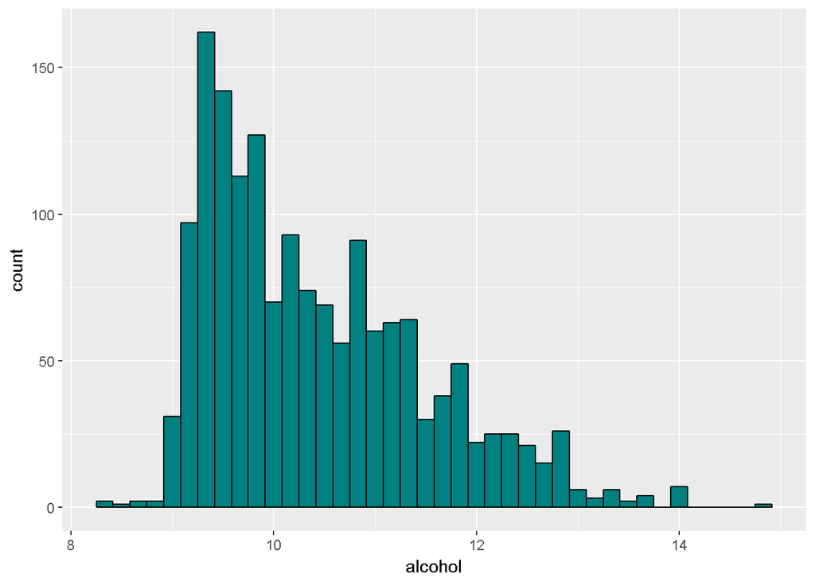

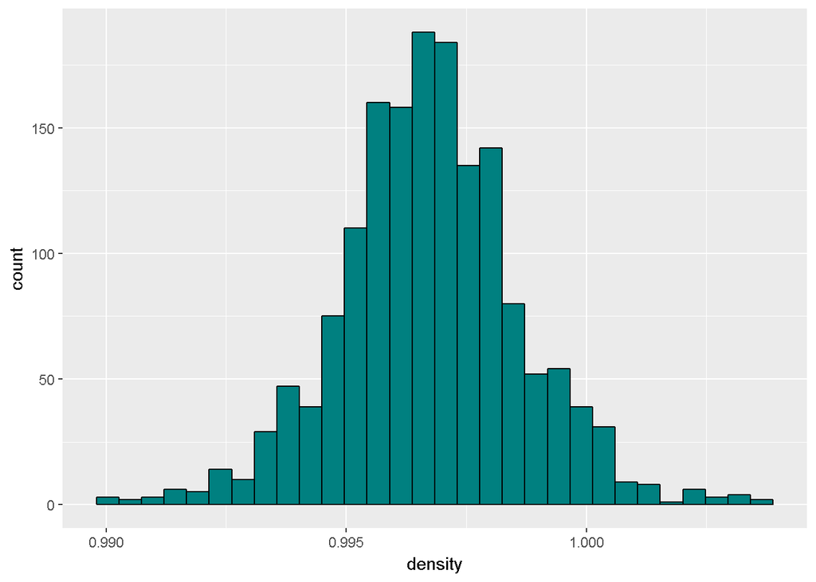

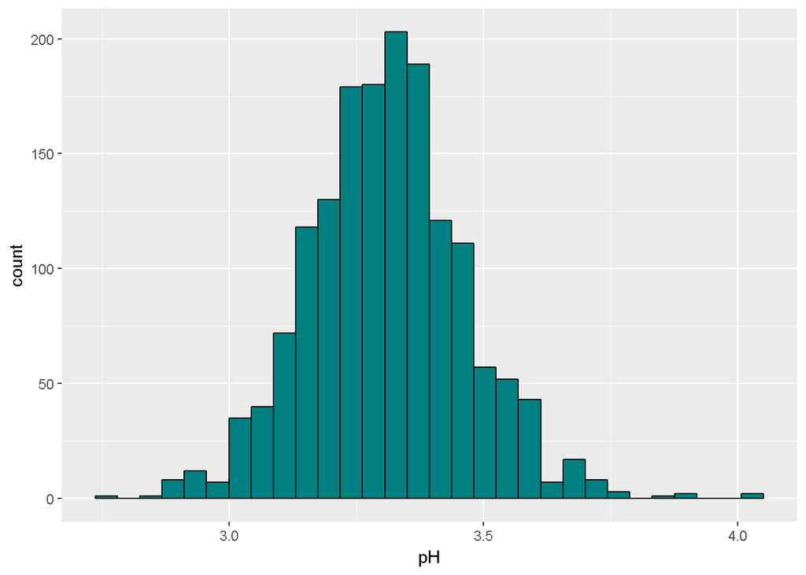

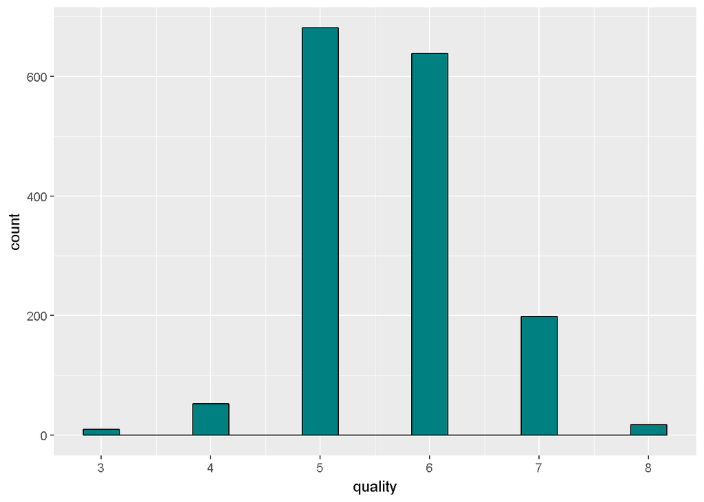

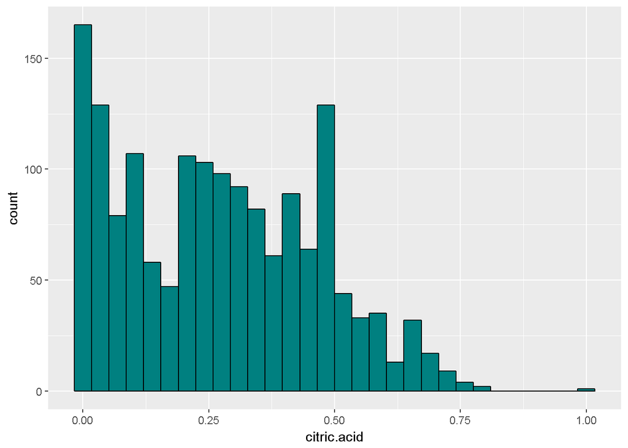

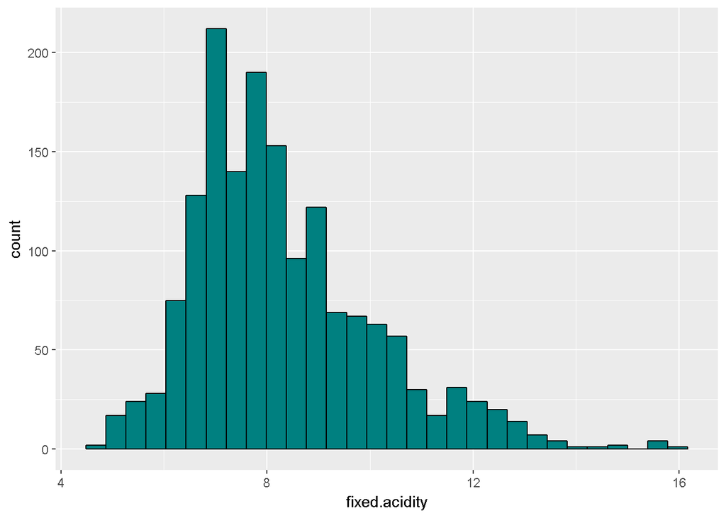

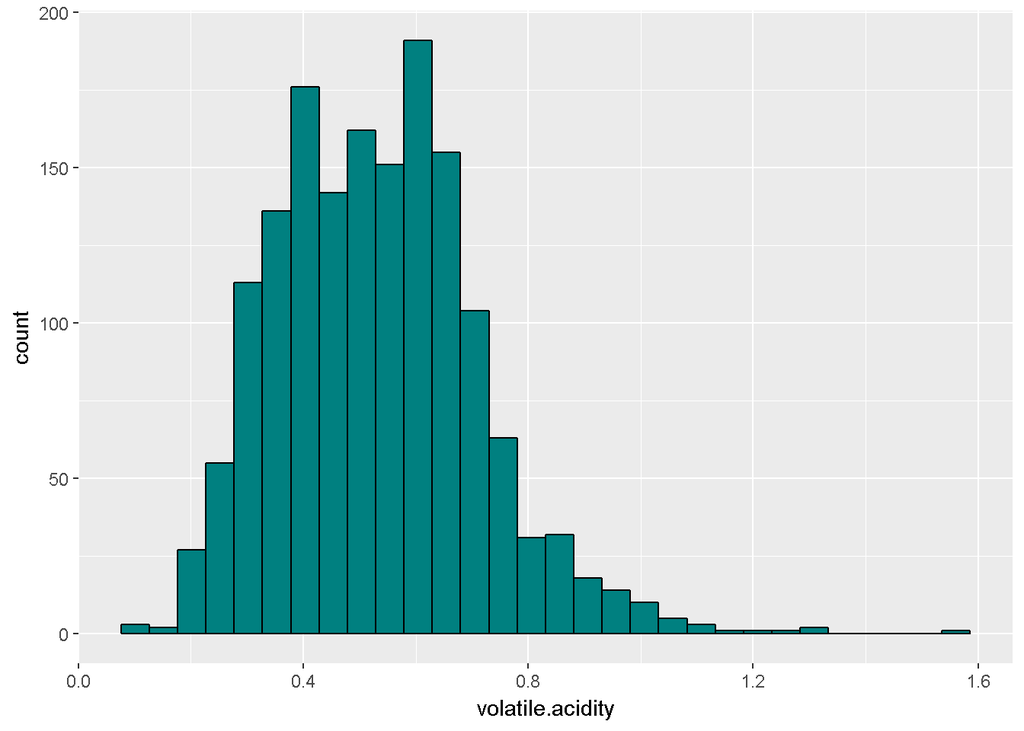

The distributions of the variables of interest either follow a normal or skewed  
distribution. The average alcohol percentage is 10.4. PH falls between a range  
of 2.7 and 4. Quality ranges from a rating of 3 to 8.

# Univariate Analysis

### What is the structure of your dataset?

The dataset contains 1599 wines, with each observation having 13  
variables corresponding to it.

### What is/are the main feature(s) of interest in your dataset?

The main features are alcohol, density, fixed and volatile acidity, and pH.  
These are metricsI’ve heard people talk about when tasting wine.

### What other features in the dataset do you think will help support your investigation into your feature(s) of interest?

When looking at fixed and volatile acidity it will be helpful to see the  
relationship they have with citric acid and pH.

### Did you create any new variables from existing variables in the dataset?

No new variables were created.

### Of the features you investigated, were there any unusual distributions? Did you perform any operations on the data to tidy, adjust, or change the form of the data? If so, why did you do this?

There were no unusual distributions, they were all either normal or skewed to  
one side. I did not perform any operations on the data.

# Bivariate Plots Section

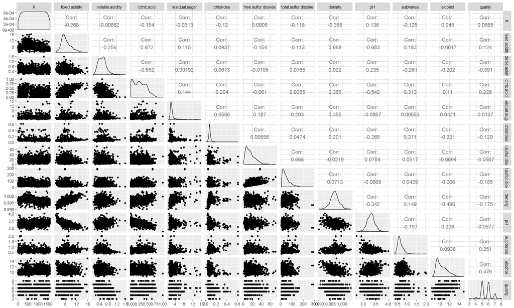

Running ggpairs, quality was most strongly correlated with alcohol and  
volatile acidity. Fixed acidity was strongly correlated with density, pH and  
citric acid.

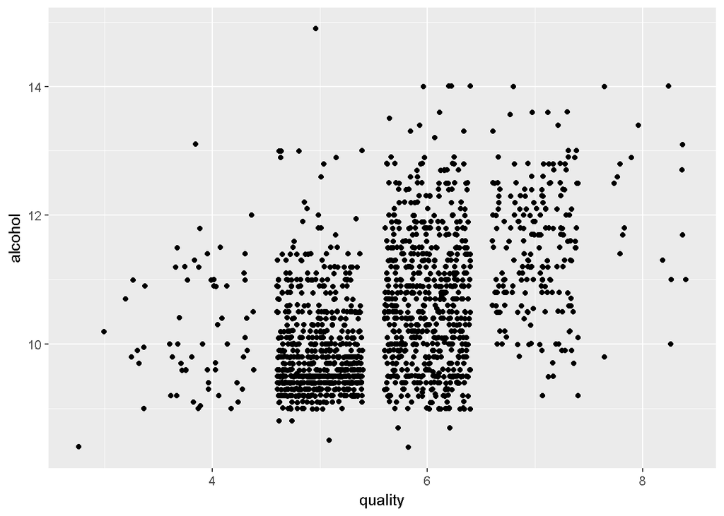

There is a positive correlation between alcohol and quality.

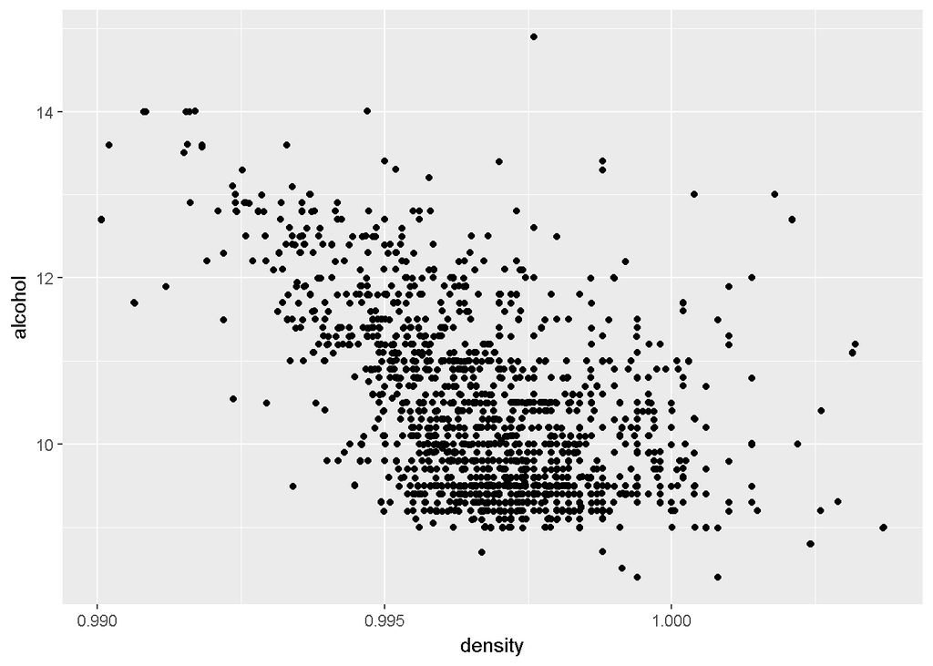

There is a moderate correlation between alcohol and density.

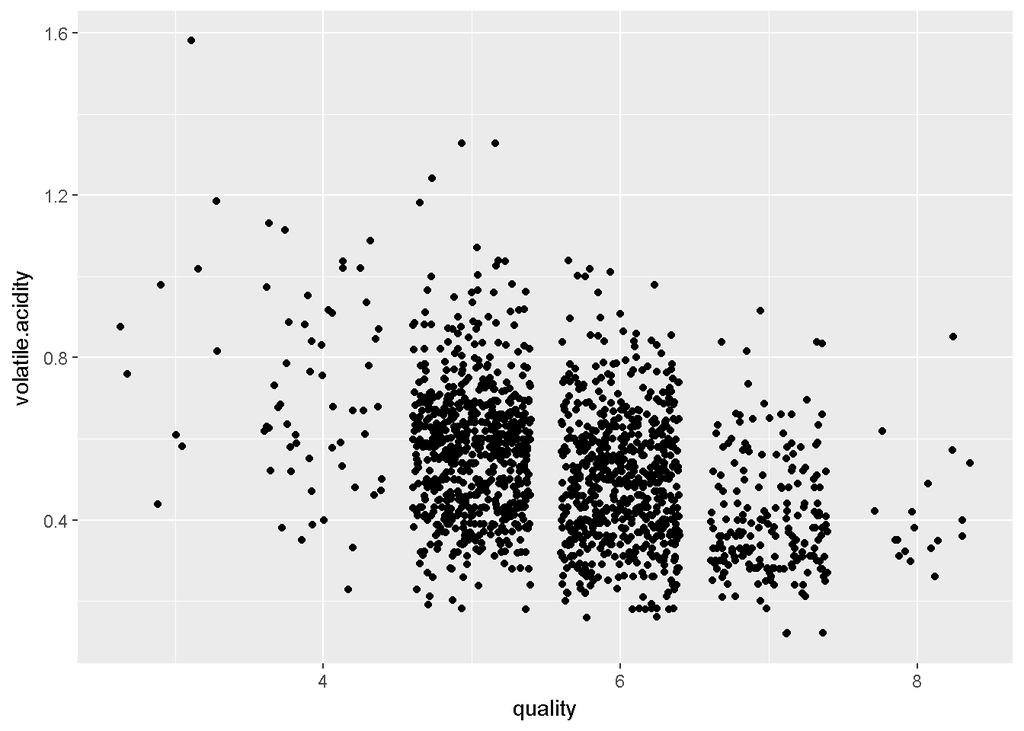

There is a negative correlation between volatile acidity and quality, it also  
appears that the range of values for volatile.acidity decrease as quality  
increases.

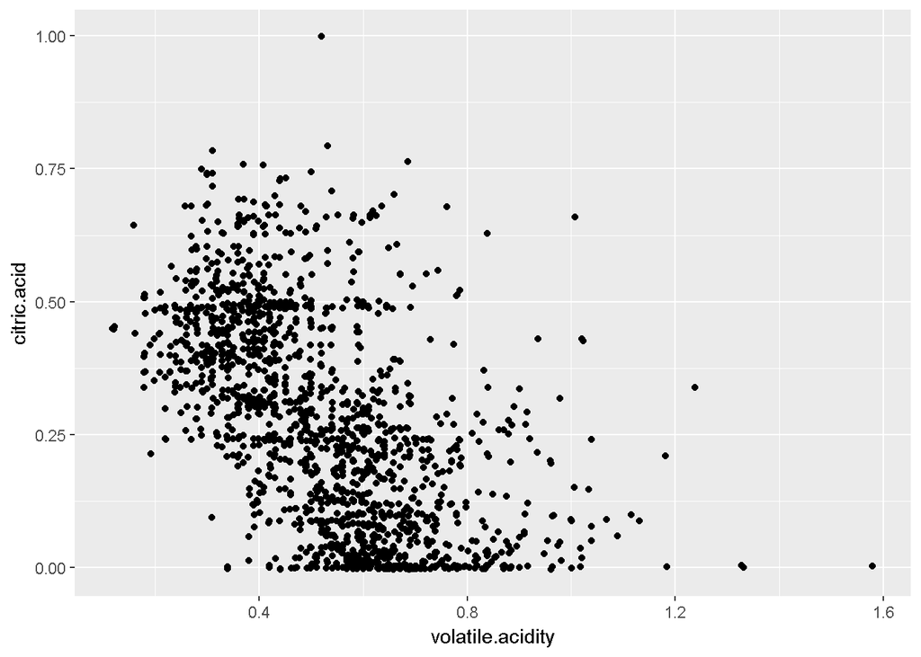

There is a negative correlation between the two variables, the higher the  
volatile acidity, the lower amount of citric acid.

# Bivariate Analysis

### Talk about some of the relationships you observed in this part of the investigation. How did the feature(s) of interest vary with other features in the dataset?

Alcohol and volatile acidity had the strongest correlation to quality. Density  
had a strong relatinship to alcohol, and volatile and citric acid were also  
strongly correlated. I had thought sulphates would be related to quality,  
however there weren’t any notable relationships.

### Did you observe any interesting relationships between the other features (not the main feature(s) of interest)?

There appeared to be a relationship between all the varibles having to do with  
acid (pH, fixed.acidity, volatile.acidity, and citric.acid), it will be  
interesting to do a multivariate analysis between them.

### What was the strongest relationship you found?

The strongest relationship was between fixed acidity and pH. This was an  
expected relationship since wine gets most of it’s acidity from the grapes  
themselves, and pH is a measure of overall acidity.

# Multivariate Plots Section

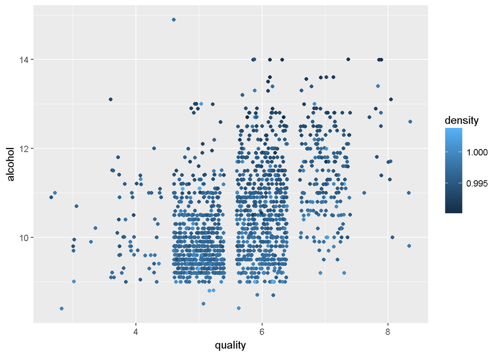

We can see here that although density and quality aren’t strongly correlated,  
there appears to be a trend where as alcohol and quality rise, density also  
seems to decrease.

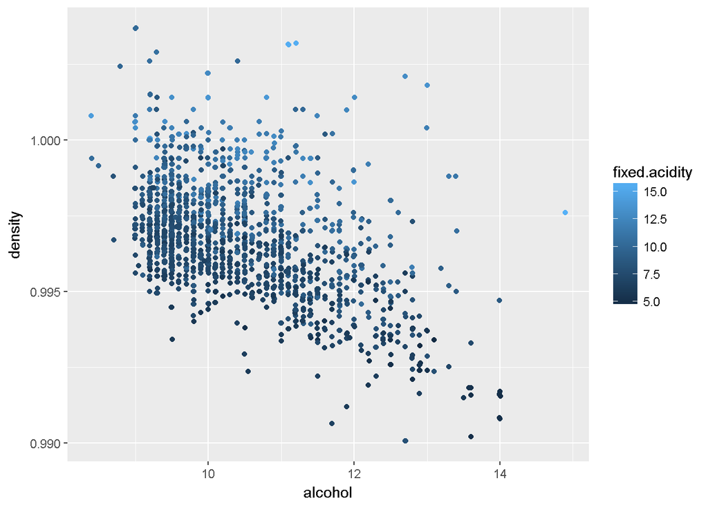

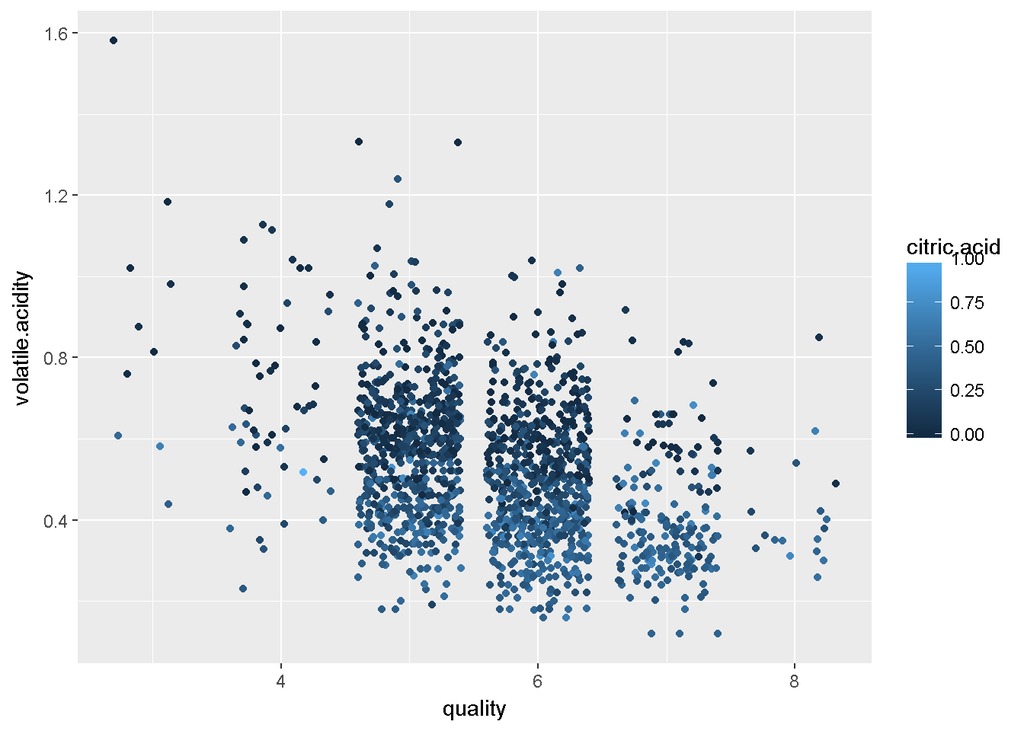

Volatile acidity had the second strongest correlation to quality, and was  
negatively correlated with citric acid. In this plot we can see both the  
negative correlation between volatile acidity and quality, and the negative  
correlation between volatile acidity and citric acid.

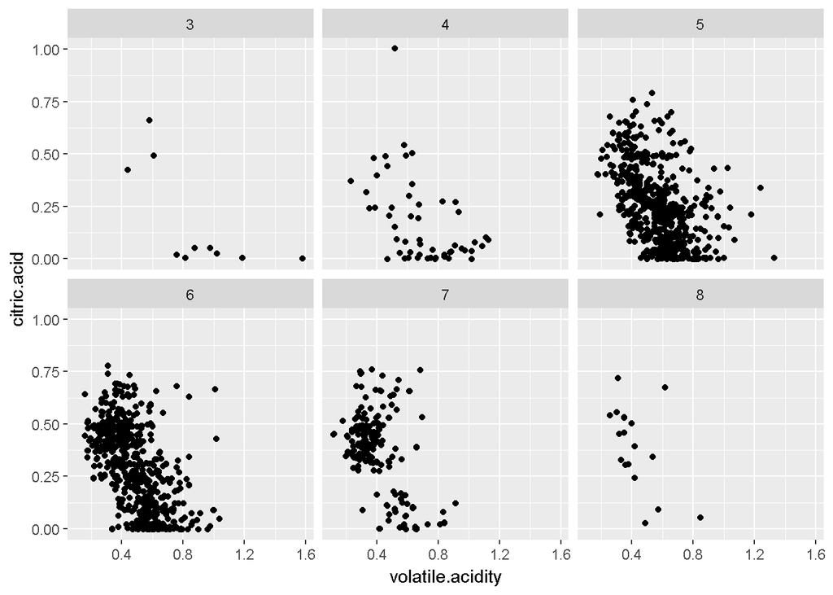

Here I wanted to see if the correlation between volatile acidity and citric  
acid changed as quality increased, it doesn’t appear to make a difference.

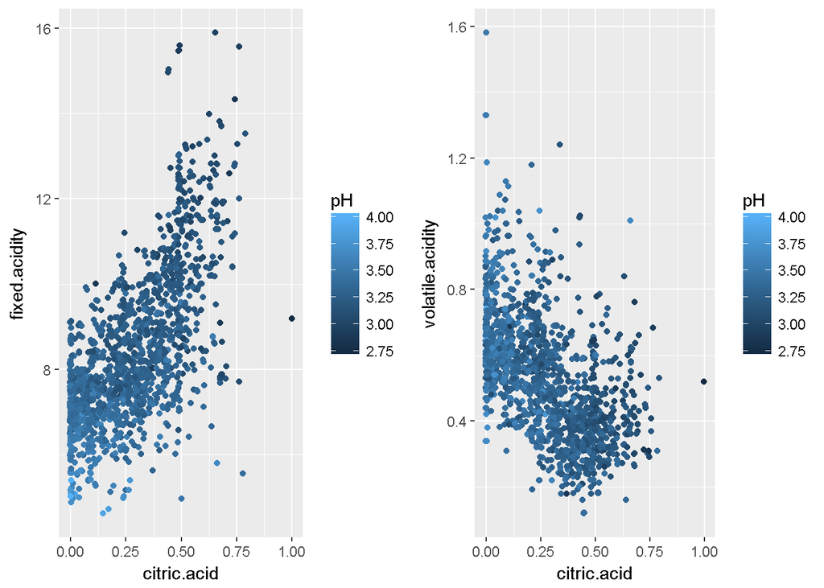

# Multivariate Analysis

# Final Plots and Summary

### Plot One

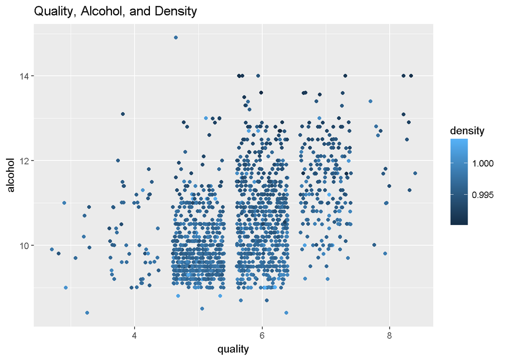

This plot shows the relationship between alcohol and quality, as well as the  
relationship between alcohol and density. As the quality of wine increases  
there is a positive correlation with the percentage of alcohol and an overall  
decrease in the wine’s density.

### Plot Two

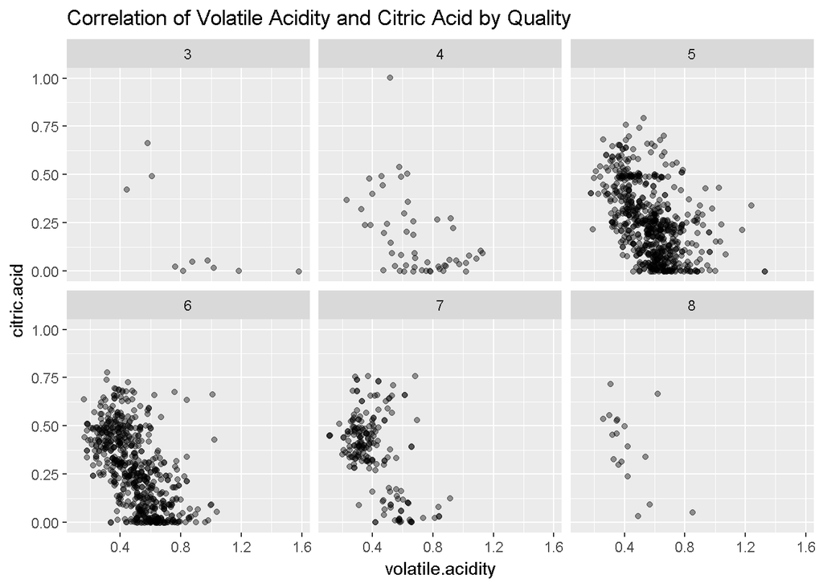

### Plot Three

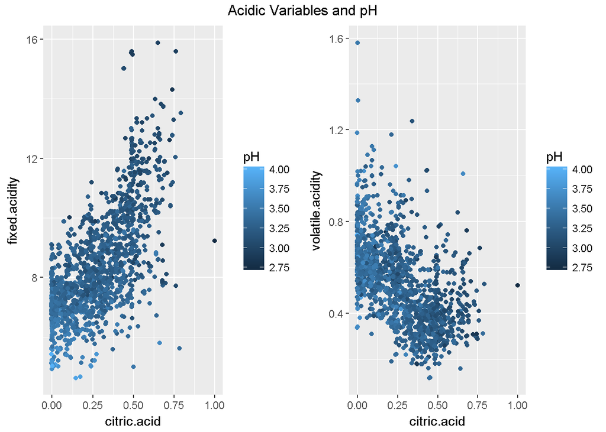

# Reflection

It appears that there is not a single variable that can predict the quality of  
a wine, it is the combination of many variables. Alcohol and volatile acidity  
are correlated with quality, but they also have correlations with other  
variables in the dataset. I have almost no background in wine, so I struggled  
in the beginning to understand what each of the variables was measuring. I  
would like to know more about the sample of wines, where it was from and what  
the ages were of each wine. In the future further analysis could be done with  
the sulpher-related variables, I have heard the term when people talk about  
wine, but did not find any meaningful relationships during my analysis. Also a  
linear model could be built to predict a wine’s quality.